# Causal Impact on Leads Generation

# Interpretation

Now we have the data ready to verify the causal effect of the campaign.

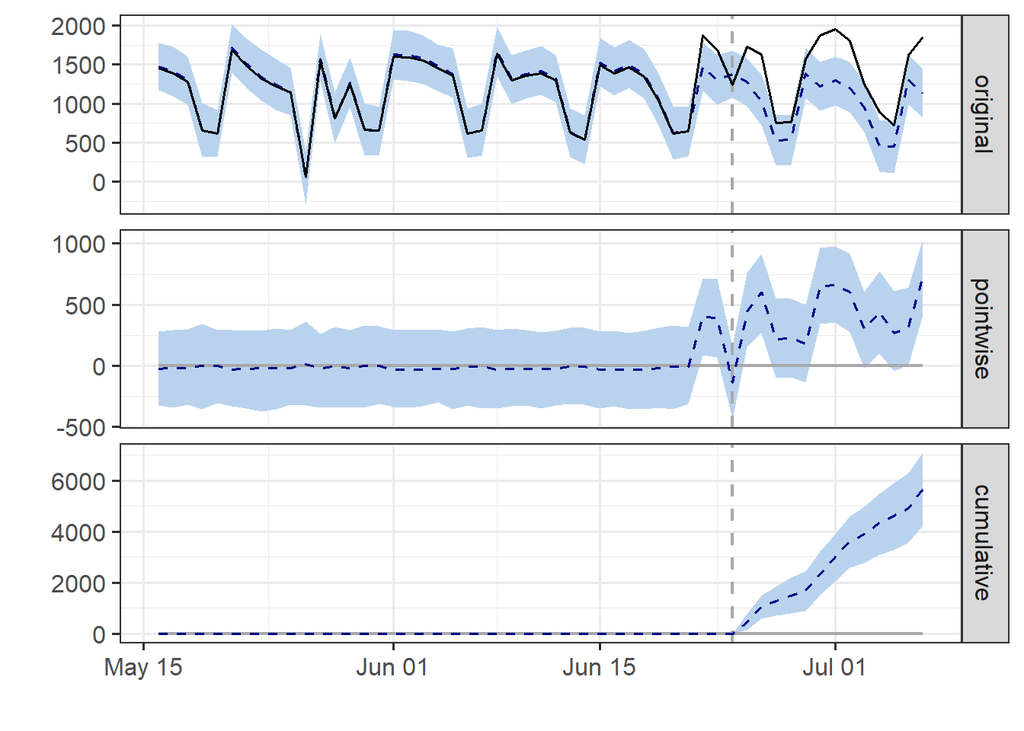

```r
impact <- CausalImpact(data = data_ci, pre.period = pre, post.period = post)
plot(impact)
```

By default, the plot contains three panels. The `original` first panel shows *counter-factual* data and predictions for the post campaign period. The second panel `pointwise` shows the difference between the actual observed (leads) and the predicted data. The third `cumulative` panel describes the cumulative effects of the intervention (campaign) conducted.

These results assume that the relationship between leads generation and the observed time series, as determined during the pre-period, remains stable throughout the post-period. We can view the statistical information by using the command `summary(impact)`

```r
summary(impact)
```

```
#> Posterior inference {CausalImpact}
#>
#>                          Average       Cumulative
#> Actual                   1417          18424
#> Prediction (s.d.)        982 (56)      12768 (731)
#> 95% CI                   [871, 1091]   [11329, 14184]
#>
#> Absolute effect (s.d.)   435 (56)      5656 (731)
#> 95% CI                   [326, 546]    [4240, 7095]
#>
#> Relative effect (s.d.)   45% (8.4%)    45% (8.4%)
#> 95% CI                   [30%, 63%]    [30%, 63%]
#>
#> Posterior tail-area probability p:   0.001
#> Posterior prob. of a causal effect:  99.8997%
#>
#> For more details, type: summary(impact, "report")
```

For guidance on correct interpretation of summary table results, the CausalImpact packages provide its interpretation text, which we can print using the command:

```r
interpretation <- summary(impact, "report")
```

[output not shown]